# Risk Factor Analysis

## Outcome Variable

**Outcome Variable:** pers_wast

## Predictor Variables

**Intervention Variable:** exclfeed36

**Adjustment Set:**

unadjusted

## Stratifying Variables

The analysis was stratified on these variable(s):

- agecat
- studyid
- country

## Data Summary

| agecat | studyid | country | exclfeed36 | pers_wast | n_cell | n |
| --- | --- | --- | --- | --- | --- | --- |
| 0-24 months | ki0047075b-MAL-ED | BANGLADESH | 0 | 0 | 173 | 247 |
| 0-24 months | ki0047075b-MAL-ED | BANGLADESH | 0 | 1 | 10 | 247 |
| 0-24 months | ki0047075b-MAL-ED | BANGLADESH | 1 | 0 | 61 | 247 |
| 0-24 months | ki0047075b-MAL-ED | BANGLADESH | 1 | 1 | 3 | 247 |
| 0-24 months | ki0047075b-MAL-ED | BRAZIL | 0 | 0 | 197 | 217 |
| 0-24 months | ki0047075b-MAL-ED | BRAZIL | 0 | 1 | 2 | 217 |
| 0-24 months | ki0047075b-MAL-ED | BRAZIL | 1 | 0 | 18 | 217 |
| 0-24 months | ki0047075b-MAL-ED | BRAZIL | 1 | 1 | 0 | 217 |
| 0-24 months | ki0047075b-MAL-ED | INDIA | 0 | 0 | 213 | 241 |
| 0-24 months | ki0047075b-MAL-ED | INDIA | 0 | 1 | 21 | 241 |
| 0-24 months | ki0047075b-MAL-ED | INDIA | 1 | 0 | 7 | 241 |
| 0-24 months | ki0047075b-MAL-ED | INDIA | 1 | 1 | 0 | 241 |
| 0-24 months | ki0047075b-MAL-ED | NEPAL | 0 | 0 | 219 | 238 |
| 0-24 months | ki0047075b-MAL-ED | NEPAL | 0 | 1 | 4 | 238 |
| 0-24 months | ki0047075b-MAL-ED | NEPAL | 1 | 0 | 15 | 238 |
| 0-24 months | ki0047075b-MAL-ED | NEPAL | 1 | 1 | 0 | 238 |
| 0-24 months | ki0047075b-MAL-ED | PERU | 0 | 0 | 265 | 282 |
| 0-24 months | ki0047075b-MAL-ED | PERU | 0 | 1 | 1 | 282 |
| 0-24 months | ki0047075b-MAL-ED | PERU | 1 | 0 | 16 | 282 |
| 0-24 months | ki0047075b-MAL-ED | PERU | 1 | 1 | 0 | 282 |
| 0-24 months | ki0047075b-MAL-ED | SOUTH AFRICA | 0 | 0 | 271 | 273 |
| 0-24 months | ki0047075b-MAL-ED | SOUTH AFRICA | 0 | 1 | 2 | 273 |
| 0-24 months | ki0047075b-MAL-ED | SOUTH AFRICA | 1 | 0 | 0 | 273 |
| 0-24 months | ki0047075b-MAL-ED | SOUTH AFRICA | 1 | 1 | 0 | 273 |
| 0-24 months | ki0047075b-MAL-ED | TANZANIA, UNITED REPUBLIC OF | 0 | 0 | 252 | 253 |
| 0-24 months | ki0047075b-MAL-ED | TANZANIA, UNITED REPUBLIC OF | 0 | 1 | 0 | 253 |
| 0-24 months | ki0047075b-MAL-ED | TANZANIA, UNITED REPUBLIC OF | 1 | 0 | 1 | 253 |
| 0-24 months | ki0047075b-MAL-ED | TANZANIA, UNITED REPUBLIC OF | 1 | 1 | 0 | 253 |
| 0-24 months | ki1000108-CMC-V-BCS-2002 | INDIA | 0 | 0 | 0 | 9 |
| 0-24 months | ki1000108-CMC-V-BCS-2002 | INDIA | 0 | 1 | 0 | 9 |

[output cut: 154 more lines]

The following strata were considered:

- agecat: 0-24 months, studyid: ki0047075b-MAL-ED, country: BANGLADESH
- agecat: 0-24 months, studyid: ki0047075b-MAL-ED, country: BRAZIL
- agecat: 0-24 months, studyid: ki0047075b-MAL-ED, country: INDIA
- agecat: 0-24 months, studyid: ki0047075b-MAL-ED, country: NEPAL
- agecat: 0-24 months, studyid: ki0047075b-MAL-ED, country: PERU
- agecat: 0-24 months, studyid: ki0047075b-MAL-ED, country: SOUTH AFRICA
- agecat: 0-24 months, studyid: ki0047075b-MAL-ED, country: TANZANIA, UNITED REPUBLIC OF
- agecat: 0-24 months, studyid: ki1000108-CMC-V-BCS-2002, country: INDIA
- agecat: 0-24 months, studyid: ki1000108-IRC, country: INDIA
- agecat: 0-24 months, studyid: ki1000109-EE, country: PAKISTAN
- agecat: 0-24 months, studyid: ki1000304b-SAS-FoodSuppl, country: INDIA
- agecat: 0-24 months, studyid: ki1017093b-PROVIDE, country: BANGLADESH
- agecat: 0-24 months, studyid: ki1101329-Keneba, country: GAMBIA
- agecat: 0-24 months, studyid: ki1113344-GMS-Nepal, country: NEPAL
- agecat: 0-24 months, studyid: ki1148112-LCNI-5, country: MALAWI
- agecat: 0-24 months, studyid: kiGH5241-JiVitA-3, country: BANGLADESH
- agecat: 0-24 months, studyid: kiGH5241-JiVitA-4, country: BANGLADESH
- agecat: 0-6 months, studyid: ki0047075b-MAL-ED, country: BANGLADESH
- agecat: 0-6 months, studyid: ki0047075b-MAL-ED, country: BRAZIL
- agecat: 0-6 months, studyid: ki0047075b-MAL-ED, country: INDIA
- agecat: 0-6 months, studyid: ki0047075b-MAL-ED, country: NEPAL
- agecat: 0-6 months, studyid: ki0047075b-MAL-ED, country: PERU
- agecat: 0-6 months, studyid: ki0047075b-MAL-ED, country: SOUTH AFRICA
- agecat: 0-6 months, studyid: ki0047075b-MAL-ED, country: TANZANIA, UNITED REPUBLIC OF
- agecat: 0-6 months, studyid: ki1000108-CMC-V-BCS-2002, country: INDIA
- agecat: 0-6 months, studyid: ki1000108-IRC, country: INDIA
- agecat: 0-6 months, studyid: ki1000109-EE, country: PAKISTAN
- agecat: 0-6 months, studyid: ki1017093b-PROVIDE, country: BANGLADESH
- agecat: 0-6 months, studyid: ki1101329-Keneba, country: GAMBIA
- agecat: 0-6 months, studyid: ki1113344-GMS-Nepal, country: NEPAL
- agecat: 6-24 months, studyid: ki0047075b-MAL-ED, country: BANGLADESH
- agecat: 6-24 months, studyid: ki0047075b-MAL-ED, country: BRAZIL
- agecat: 6-24 months, studyid: ki0047075b-MAL-ED, country: INDIA
- agecat: 6-24 months, studyid: ki0047075b-MAL-ED, country: NEPAL
- agecat: 6-24 months, studyid: ki0047075b-MAL-ED, country: PERU
- agecat: 6-24 months, studyid: ki0047075b-MAL-ED, country: SOUTH AFRICA
- agecat: 6-24 months, studyid: ki0047075b-MAL-ED, country: TANZANIA, UNITED REPUBLIC OF
- agecat: 6-24 months, studyid: ki1000108-CMC-V-BCS-2002, country: INDIA
- agecat: 6-24 months, studyid: ki1000108-IRC, country: INDIA
- agecat: 6-24 months, studyid: ki1000109-EE, country: PAKISTAN
- agecat: 6-24 months, studyid: ki1000304b-SAS-FoodSuppl, country: INDIA
- agecat: 6-24 months, studyid: ki1017093b-PROVIDE, country: BANGLADESH
- agecat: 6-24 months, studyid: ki1101329-Keneba, country: GAMBIA
- agecat: 6-24 months, studyid: ki1113344-GMS-Nepal, country: NEPAL
- agecat: 6-24 months, studyid: ki1148112-LCNI-5, country: MALAWI
- agecat: 6-24 months, studyid: kiGH5241-JiVitA-4, country: BANGLADESH

### Dropped Strata

Some strata were dropped due to rare outcomes:

- agecat: 0-24 months, studyid: ki0047075b-MAL-ED, country: BANGLADESH
- agecat: 0-24 months, studyid: ki0047075b-MAL-ED, country: BRAZIL
- agecat: 0-24 months, studyid: ki0047075b-MAL-ED, country: INDIA
- agecat: 0-24 months, studyid: ki0047075b-MAL-ED, country: NEPAL
- agecat: 0-24 months, studyid: ki0047075b-MAL-ED, country: PERU
- agecat: 0-24 months, studyid: ki0047075b-MAL-ED, country: SOUTH AFRICA
- agecat: 0-24 months, studyid: ki0047075b-MAL-ED, country: TANZANIA, UNITED REPUBLIC OF
- agecat: 0-24 months, studyid: ki1000108-CMC-V-BCS-2002, country: INDIA
- agecat: 0-24 months, studyid: ki1000108-IRC, country: INDIA
- agecat: 0-24 months, studyid: ki1000304b-SAS-FoodSuppl, country: INDIA
- agecat: 0-24 months, studyid: ki1017093b-PROVIDE, country: BANGLADESH
- agecat: 0-24 months, studyid: ki1148112-LCNI-5, country: MALAWI
- agecat: 0-6 months, studyid: ki0047075b-MAL-ED, country: BANGLADESH
- agecat: 0-6 months, studyid: ki0047075b-MAL-ED, country: BRAZIL
- agecat: 0-6 months, studyid: ki0047075b-MAL-ED, country: INDIA
- agecat: 0-6 months, studyid: ki0047075b-MAL-ED, country: NEPAL
- agecat: 0-6 months, studyid: ki0047075b-MAL-ED, country: PERU
- agecat: 0-6 months, studyid: ki0047075b-MAL-ED, country: SOUTH AFRICA
- agecat: 0-6 months, studyid: ki0047075b-MAL-ED, country: TANZANIA, UNITED REPUBLIC OF
- agecat: 0-6 months, studyid: ki1000108-CMC-V-BCS-2002, country: INDIA
- agecat: 0-6 months, studyid: ki1000108-IRC, country: INDIA
- agecat: 0-6 months, studyid: ki1017093b-PROVIDE, country: BANGLADESH
- agecat: 6-24 months, studyid: ki0047075b-MAL-ED, country: BRAZIL
- agecat: 6-24 months, studyid: ki0047075b-MAL-ED, country: INDIA
- agecat: 6-24 months, studyid: ki0047075b-MAL-ED, country: NEPAL
- agecat: 6-24 months, studyid: ki0047075b-MAL-ED, country: PERU
- agecat: 6-24 months, studyid: ki0047075b-MAL-ED, country: SOUTH AFRICA
- agecat: 6-24 months, studyid: ki0047075b-MAL-ED, country: TANZANIA, UNITED REPUBLIC OF
- agecat: 6-24 months, studyid: ki1000108-CMC-V-BCS-2002, country: INDIA
- agecat: 6-24 months, studyid: ki1000108-IRC, country: INDIA
- agecat: 6-24 months, studyid: ki1000304b-SAS-FoodSuppl, country: INDIA
- agecat: 6-24 months, studyid: ki1148112-LCNI-5, country: MALAWI

## Methods Detail

We’re interested in the causal parameters $E[Y_a]$ for all values of $a \in \mathcal{A}$. These parameters represent the mean outcome if, possibly contrary to fact, we intervened to set all units to have $A=a$. Under the randomization and positivity assumptions, these are identified by the statistical parameters $\psi_a=E_W[E_{Y|A,W}(Y|A=a,W)]$. In addition, we’re interested in the mean of $Y$, $E[Y]$ under no intervention (the observed mean). We will estimate these parameters by using SuperLearner to fit the relevant likelihood factors – $E_{Y|A,W}(Y|A=a,W)$ and $p(A=a|W)$, and then updating our likelihood fit using a joint TMLE.

For unadjusted analyses ($W=\{\}$), initial likelihoods were estimated using Lrnr_glm to estimate the simple $E(Y|A)$ and Lrnr_mean to estimate $p(A)$. For adjusted analyses, a small library containing Lrnr_glmnet, Lrnr_xgboost, and Lrnr_mean was used.

Having estimated these parameters, we will then use the delta method to estimate relative risks and attributable risks relative to a prespecified baseline level of $A$.

# Results Detail

## Results Plots

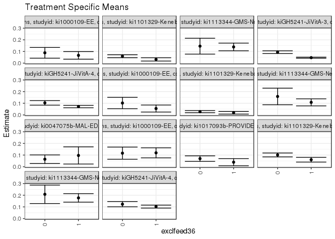

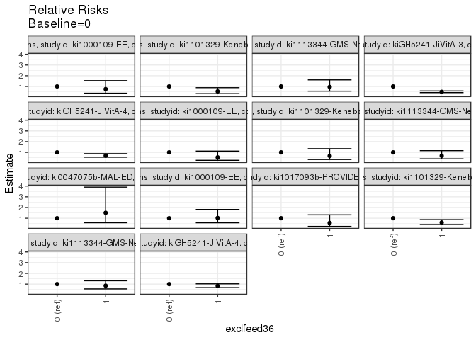

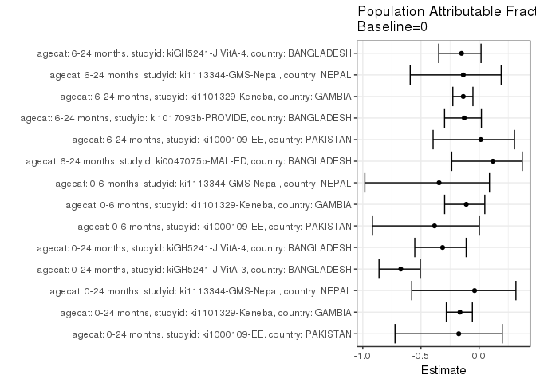

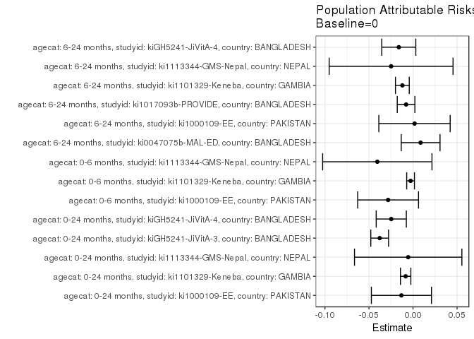

## Results Table

### Parameter: TSM

| agecat | studyid | country | intervention_level | baseline_level | estimate | ci_lower | ci_upper |
| --- | --- | --- | --- | --- | --- | --- | --- |
| 0-24 months | ki1000109-EE | PAKISTAN | 0 | NA | 0.0884354 | 0.0424753 | 0.1343954 |
| 0-24 months | ki1000109-EE | PAKISTAN | 1 | NA | 0.0666667 | 0.0340294 | 0.0993040 |
| 0-24 months | ki1101329-Keneba | GAMBIA | 0 | NA | 0.0592204 | 0.0465508 | 0.0718900 |
| 0-24 months | ki1101329-Keneba | GAMBIA | 1 | NA | 0.0320405 | 0.0178626 | 0.0462184 |
| 0-24 months | ki1113344-GMS-Nepal | NEPAL | 0 | NA | 0.1456311 | 0.0774457 | 0.2138164 |
| 0-24 months | ki1113344-GMS-Nepal | NEPAL | 1 | NA | 0.1388235 | 0.1059200 | 0.1717271 |
| 0-24 months | kiGH5241-JiVitA-3 | BANGLADESH | 0 | NA | 0.0940340 | 0.0823021 | 0.1057659 |
| 0-24 months | kiGH5241-JiVitA-3 | BANGLADESH | 1 | NA | 0.0468780 | 0.0422443 | 0.0515118 |
| 0-24 months | kiGH5241-JiVitA-4 | BANGLADESH | 0 | NA | 0.1034483 | 0.0839379 | 0.1229587 |
| 0-24 months | kiGH5241-JiVitA-4 | BANGLADESH | 1 | NA | 0.0717566 | 0.0613752 | 0.0821380 |
| 0-6 months | ki1000109-EE | PAKISTAN | 0 | NA | 0.1020408 | 0.0530405 | 0.1510411 |
| 0-6 months | ki1000109-EE | PAKISTAN | 1 | NA | 0.0547945 | 0.0246123 | 0.0849768 |
| 0-6 months | ki1101329-Keneba | GAMBIA | 0 | NA | 0.0279776 | 0.0188368 | 0.0371184 |
| 0-6 months | ki1101329-Keneba | GAMBIA | 1 | NA | 0.0186916 | 0.0072122 | 0.0301710 |
| 0-6 months | ki1113344-GMS-Nepal | NEPAL | 0 | NA | 0.1584158 | 0.0871367 | 0.2296950 |
| 0-6 months | ki1113344-GMS-Nepal | NEPAL | 1 | NA | 0.1078431 | 0.0777157 | 0.1379706 |
| 6-24 months | ki0047075b-MAL-ED | BANGLADESH | 0 | NA | 0.0643275 | 0.0274769 | 0.1011781 |
| 6-24 months | ki0047075b-MAL-ED | BANGLADESH | 1 | NA | 0.0967742 | 0.0230238 | 0.1705246 |
| 6-24 months | ki1000109-EE | PAKISTAN | 0 | NA | 0.1164384 | 0.0643386 | 0.1685381 |
| 6-24 months | ki1000109-EE | PAKISTAN | 1 | NA | 0.1192661 | 0.0761838 | 0.1623483 |
| 6-24 months | ki1017093b-PROVIDE | BANGLADESH | 0 | NA | 0.0696629 | 0.0459900 | 0.0933358 |
| 6-24 months | ki1017093b-PROVIDE | BANGLADESH | 1 | NA | 0.0389610 | 0.0083741 | 0.0695480 |
| 6-24 months | ki1101329-Keneba | GAMBIA | 0 | NA | 0.1008737 | 0.0842336 | 0.1175138 |
| 6-24 months | ki1101329-Keneba | GAMBIA | 1 | NA | 0.0601504 | 0.0399406 | 0.0803602 |
| 6-24 months | ki1113344-GMS-Nepal | NEPAL | 0 | NA | 0.2079208 | 0.1286999 | 0.2871416 |
| 6-24 months | ki1113344-GMS-Nepal | NEPAL | 1 | NA | 0.1770335 | 0.1404068 | 0.2136602 |
| 6-24 months | kiGH5241-JiVitA-4 | BANGLADESH | 0 | NA | 0.1231263 | 0.1005074 | 0.1457452 |
| 6-24 months | kiGH5241-JiVitA-4 | BANGLADESH | 1 | NA | 0.1024566 | 0.0897776 | 0.1151355 |

### Parameter: E(Y)

| agecat | studyid | country | intervention_level | baseline_level | estimate | ci_lower | ci_upper |
| --- | --- | --- | --- | --- | --- | --- | --- |
| 0-24 months | ki1000109-EE | PAKISTAN | NA | NA | 0.0752688 | 0.0484230 | 0.1021146 |
| 0-24 months | ki1101329-Keneba | GAMBIA | NA | NA | 0.0508563 | 0.0410442 | 0.0606683 |
| 0-24 months | ki1113344-GMS-Nepal | NEPAL | NA | NA | 0.1401515 | 0.1105133 | 0.1697898 |
| 0-24 months | kiGH5241-JiVitA-3 | BANGLADESH | NA | NA | 0.0561929 | 0.0517926 | 0.0605933 |
| 0-24 months | kiGH5241-JiVitA-4 | BANGLADESH | NA | NA | 0.0787472 | 0.0695071 | 0.0879873 |
| 0-6 months | ki1000109-EE | PAKISTAN | NA | NA | 0.0737705 | 0.0469540 | 0.1005870 |
| 0-6 months | ki1101329-Keneba | GAMBIA | NA | NA | 0.0251960 | 0.0179257 | 0.0324663 |
| 0-6 months | ki1113344-GMS-Nepal | NEPAL | NA | NA | 0.1178782 | 0.0898370 | 0.1459194 |
| 6-24 months | ki0047075b-MAL-ED | BANGLADESH | NA | NA | 0.0729614 | 0.0394957 | 0.1064270 |
| 6-24 months | ki1000109-EE | PAKISTAN | NA | NA | 0.1181319 | 0.0849287 | 0.1513351 |
| 6-24 months | ki1017093b-PROVIDE | BANGLADESH | NA | NA | 0.0617696 | 0.0424748 | 0.0810644 |
| 6-24 months | ki1101329-Keneba | GAMBIA | NA | NA | 0.0887772 | 0.0756012 | 0.1019533 |
| 6-24 months | ki1113344-GMS-Nepal | NEPAL | NA | NA | 0.1830443 | 0.1497431 | 0.2163456 |
| 6-24 months | kiGH5241-JiVitA-4 | BANGLADESH | NA | NA | 0.1069757 | 0.0954392 | 0.1185121 |

### Parameter: RR

| agecat | studyid | country | intervention_level | baseline_level | estimate | ci_lower | ci_upper |
| --- | --- | --- | --- | --- | --- | --- | --- |
| 0-24 months | ki1000109-EE | PAKISTAN | 0 | 0 | 1.0000000 | 1.0000000 | 1.0000000 |
| 0-24 months | ki1000109-EE | PAKISTAN | 1 | 0 | 0.7538462 | 0.3691541 | 1.5394220 |
| 0-24 months | ki1101329-Keneba | GAMBIA | 0 | 0 | 1.0000000 | 1.0000000 | 1.0000000 |
| 0-24 months | ki1101329-Keneba | GAMBIA | 1 | 0 | 0.5410378 | 0.3309561 | 0.8844738 |
| 0-24 months | ki1113344-GMS-Nepal | NEPAL | 0 | 0 | 1.0000000 | 1.0000000 | 1.0000000 |
| 0-24 months | ki1113344-GMS-Nepal | NEPAL | 1 | 0 | 0.9532549 | 0.5640272 | 1.6110834 |
| 0-24 months | kiGH5241-JiVitA-3 | BANGLADESH | 0 | 0 | 1.0000000 | 1.0000000 | 1.0000000 |
| 0-24 months | kiGH5241-JiVitA-3 | BANGLADESH | 1 | 0 | 0.4985223 | 0.4254920 | 0.5840875 |
| 0-24 months | kiGH5241-JiVitA-4 | BANGLADESH | 0 | 0 | 1.0000000 | 1.0000000 | 1.0000000 |
| 0-24 months | kiGH5241-JiVitA-4 | BANGLADESH | 1 | 0 | 0.6936471 | 0.5482857 | 0.8775468 |
| 0-6 months | ki1000109-EE | PAKISTAN | 0 | 0 | 1.0000000 | 1.0000000 | 1.0000000 |
| 0-6 months | ki1000109-EE | PAKISTAN | 1 | 0 | 0.5369863 | 0.2585829 | 1.1151328 |
| 0-6 months | ki1101329-Keneba | GAMBIA | 0 | 0 | 1.0000000 | 1.0000000 | 1.0000000 |
| 0-6 months | ki1101329-Keneba | GAMBIA | 1 | 0 | 0.6680908 | 0.3332121 | 1.3395231 |
| 0-6 months | ki1113344-GMS-Nepal | NEPAL | 0 | 0 | 1.0000000 | 1.0000000 | 1.0000000 |
| 0-6 months | ki1113344-GMS-Nepal | NEPAL | 1 | 0 | 0.6807598 | 0.4008504 | 1.1561267 |
| 6-24 months | ki0047075b-MAL-ED | BANGLADESH | 0 | 0 | 1.0000000 | 1.0000000 | 1.0000000 |
| 6-24 months | ki0047075b-MAL-ED | BANGLADESH | 1 | 0 | 1.5043988 | 0.5798463 | 3.9031305 |
| 6-24 months | ki1000109-EE | PAKISTAN | 0 | 0 | 1.0000000 | 1.0000000 | 1.0000000 |
| 6-24 months | ki1000109-EE | PAKISTAN | 1 | 0 | 1.0242849 | 0.5763364 | 1.8203946 |
| 6-24 months | ki1017093b-PROVIDE | BANGLADESH | 0 | 0 | 1.0000000 | 1.0000000 | 1.0000000 |
| 6-24 months | ki1017093b-PROVIDE | BANGLADESH | 1 | 0 | 0.5592795 | 0.2377437 | 1.3156759 |
| 6-24 months | ki1101329-Keneba | GAMBIA | 0 | 0 | 1.0000000 | 1.0000000 | 1.0000000 |
| 6-24 months | ki1101329-Keneba | GAMBIA | 1 | 0 | 0.5962939 | 0.4101139 | 0.8669943 |
| 6-24 months | ki1113344-GMS-Nepal | NEPAL | 0 | 0 | 1.0000000 | 1.0000000 | 1.0000000 |
| 6-24 months | ki1113344-GMS-Nepal | NEPAL | 1 | 0 | 0.8514468 | 0.5519045 | 1.3135637 |
| 6-24 months | kiGH5241-JiVitA-4 | BANGLADESH | 0 | 0 | 1.0000000 | 1.0000000 | 1.0000000 |
| 6-24 months | kiGH5241-JiVitA-4 | BANGLADESH | 1 | 0 | 0.8321255 | 0.6745071 | 1.0265759 |

### Parameter: PAR

| agecat | studyid | country | intervention_level | baseline_level | estimate | ci_lower | ci_upper |
| --- | --- | --- | --- | --- | --- | --- | --- |
| 0-24 months | ki1000109-EE | PAKISTAN | 0 | NA | -0.0131666 | -0.0472782 | 0.0209451 |
| 0-24 months | ki1101329-Keneba | GAMBIA | 0 | NA | -0.0083641 | -0.0142421 | -0.0024862 |
| 0-24 months | ki1113344-GMS-Nepal | NEPAL | 0 | NA | -0.0054796 | -0.0664202 | 0.0554610 |
| 0-24 months | kiGH5241-JiVitA-3 | BANGLADESH | 0 | NA | -0.0378410 | -0.0479211 | -0.0277610 |
| 0-24 months | kiGH5241-JiVitA-4 | BANGLADESH | 0 | NA | -0.0247011 | -0.0417967 | -0.0076054 |
| 0-6 months | ki1000109-EE | PAKISTAN | 0 | NA | -0.0282703 | -0.0627878 | 0.0062472 |
| 0-6 months | ki1101329-Keneba | GAMBIA | 0 | NA | -0.0027816 | -0.0071817 | 0.0016184 |
| 0-6 months | ki1113344-GMS-Nepal | NEPAL | 0 | NA | -0.0405376 | -0.1025918 | 0.0215165 |
| 6-24 months | ki0047075b-MAL-ED | BANGLADESH | 0 | NA | 0.0086339 | -0.0133816 | 0.0306493 |
| 6-24 months | ki1000109-EE | PAKISTAN | 0 | NA | 0.0016935 | -0.0387956 | 0.0421826 |
| 6-24 months | ki1017093b-PROVIDE | BANGLADESH | 0 | NA | -0.0078933 | -0.0178952 | 0.0021085 |
| 6-24 months | ki1101329-Keneba | GAMBIA | 0 | NA | -0.0120965 | -0.0199203 | -0.0042727 |
| 6-24 months | ki1113344-GMS-Nepal | NEPAL | 0 | NA | -0.0248765 | -0.0951777 | 0.0454247 |
| 6-24 months | kiGH5241-JiVitA-4 | BANGLADESH | 0 | NA | -0.0161507 | -0.0354529 | 0.0031515 |

### Parameter: PAF

| agecat | studyid | country | intervention_level | baseline_level | estimate | ci_lower | ci_upper |
| --- | --- | --- | --- | --- | --- | --- | --- |
| 0-24 months | ki1000109-EE | PAKISTAN | 0 | NA | -0.1749271 | -0.7228204 | 0.1987245 |
| 0-24 months | ki1101329-Keneba | GAMBIA | 0 | NA | -0.1644662 | -0.2817022 | -0.0579537 |
| 0-24 months | ki1113344-GMS-Nepal | NEPAL | 0 | NA | -0.0390973 | -0.5789517 | 0.3161771 |
| 0-24 months | kiGH5241-JiVitA-3 | BANGLADESH | 0 | NA | -0.6734130 | -0.8603511 | -0.5052594 |
| 0-24 months | kiGH5241-JiVitA-4 | BANGLADESH | 0 | NA | -0.3136755 | -0.5529887 | -0.1112402 |
| 0-6 months | ki1000109-EE | PAKISTAN | 0 | NA | -0.3832200 | -0.9170506 | 0.0019578 |
| 0-6 months | ki1101329-Keneba | GAMBIA | 0 | NA | -0.1104006 | -0.2962906 | 0.0488326 |
| 0-6 months | ki1113344-GMS-Nepal | NEPAL | 0 | NA | -0.3438944 | -0.9822754 | 0.0888995 |
| 6-24 months | ki0047075b-MAL-ED | BANGLADESH | 0 | NA | 0.1183351 | -0.2355235 | 0.3708472 |
| 6-24 months | ki1000109-EE | PAKISTAN | 0 | NA | 0.0143358 | -0.3955274 | 0.3038231 |
| 6-24 months | ki1017093b-PROVIDE | BANGLADESH | 0 | NA | -0.1277862 | -0.2970176 | 0.0193644 |
| 6-24 months | ki1101329-Keneba | GAMBIA | 0 | NA | -0.1362567 | -0.2259218 | -0.0531497 |
| 6-24 months | ki1113344-GMS-Nepal | NEPAL | 0 | NA | -0.1359041 | -0.5923325 | 0.1896930 |
| 6-24 months | kiGH5241-JiVitA-4 | BANGLADESH | 0 | NA | -0.1509753 | -0.3469269 | 0.0164692 |